# NFL data analysis and prediction of Ravens' chances for either Wild-card or Playoff

[figure not shown]

```
On 13th November 2018, I went to visit my family and friends in Baltimore. My friends and I were talking about NFL.
```

As most of us are Baltimore Ravens fans, we would love to see Ravens to win superbowl again. However, our team is not doing very this season. Some of the friends think that Ravens will be done by end of the regular season and will not play the any further for these season. In contrast to those friends, there are other friends including me who think that Ravens still can get to playoff even though they will not be group division champion, Ravens still have chances to make it through wild card entry. Two or three days later, I decided to predict whether Ravens will actually make it to the playoff or wild card entry by the end of the month so I can show the result of prediction to my friends and tell them what will more likely to happend by the end of the regular season. Addition to showing this result to my friends, I can use is as my project demo for one of my Data Science and Machine Learing class. I apply some data science and machine learning technique to do this stuff. In order to do it,first I needed to find the data that can be use for my purpose. I've found data from github where author has uploaded play by play details of each games from 2009 to presents. the best part of this data is they updated every nfl week and are in csv files which is easy to extract the information. All the procedures I have done for this are file go_ravens.ipynb, you can walk through the code, prose and comment to understand the more in detail.

Data Collection  
-----------------------  
There are csv files where each csv file contains nfl play by play details of each game  
for regular season of a single year  
We collect data from ten individual csv files to get information about nfl play by play detail  
from 2009 to 2017 and part of 2018 that are played

```python
# Libraries and classes that are going to be used through out the project
import pandas as pd
import numpy as np
import matplotlib.pyplot as plt
import numpy.polynomial.polynomial as poly
import seaborn as sns
from sklearn.model_selection import train_test_split
from sklearn.linear_model import LogisticRegression
from sklearn import preprocessing
from sklearn.metrics import classification_report
from sklearn.metrics import confusion_matrix
from sklearn.metrics import accuracy_score
import warnings
warnings.simplefilter(action='ignore', category=FutureWarning)
```

```python
file_str = 'regular_season/reg_pbp_'
start_year = 2009
csv_str='.csv'
list_for_df=[]
colnames = ['game_id', 'home_team', 'away_team', 'posteam','defteam', 'game_date', 'qb_kneel',
            'field_goal_result','td_team','total_home_score', 'total_away_score',
            'incomplete_pass', 'interception', 'qb_hit', 'sack', 'touchdown','pass_touchdown',
            'rush_touchdown', 'return_touchdown', 'fumble', 'complete_pass',   'penalty_team',
            'penalty_yards']
df=pd.DataFrame(columns=colnames)
for i in range(10):
    year=start_year+i
    year_str = str(year)
    file_name = file_str+year_str+csv_str;
    # data in csv file has more than 200 columns so to limit the reading data pass usecols which
    # save time and space
    df1 = pd.read_csv(file_name,usecols=colnames)
#     df1=df1[colnames]
    df1_len = len(df1)
    year_list = np.full((df1_len, 1), year)
    df1['year']=year_list
    df=df.append(df1)

# change datatype of year to integer
df['year']=df['year'].astype(int)

# fix the name of teams on data
# Since Rams and Chargers moved to LA from thier previous place , their names on data have been
# changed Also Jacksonville is represented by 'JAC' and later it's changed to 'JAx'.
# we replace all 'STL' to 'LA', 'SD' to 'LAC', and 'JAC' to 'JAX'
df = df.replace('STL', 'LA')
df = df.replace('SD','LAC')
df = df.replace('JAC','JAX')


df.head()
```

```
C:\Users\Pradeep Regmi\Anaconda3\lib\site-packages\IPython\core\interactiveshell.py:2785: DtypeWarning: Columns (39,47,244) have mixed types. Specify dtype option on import or set low_memory=False.
  interactivity=interactivity, compiler=compiler, result=result)
```

|  | away_team | complete_pass | defteam | field_goal_result | fumble | game_date | game_id | home_team | incomplete_pass | interception | ... | qb_hit | qb_kneel | return_touchdown | rush_touchdown | sack | td_team | total_away_score | total_home_score | touchdown | year |
| --- | --- | --- | --- | --- | --- | --- | --- | --- | --- | --- | --- | --- | --- | --- | --- | --- | --- | --- | --- | --- | --- |
| 0 | TEN | 0.0 | TEN | NaN | 0.0 | 2009-09-10 | 2009091000 | PIT | 0.0 | 0.0 | ... | 0.0 | 0 | 0.0 | 0.0 | 0.0 | NaN | 0 | 0 | 0.0 | 2009 |
| 1 | TEN | 1.0 | TEN | NaN | 0.0 | 2009-09-10 | 2009091000 | PIT | 0.0 | 0.0 | ... | 0.0 | 0 | 0.0 | 0.0 | 0.0 | NaN | 0 | 0 | 0.0 | 2009 |
| 2 | TEN | 0.0 | TEN | NaN | 0.0 | 2009-09-10 | 2009091000 | PIT | 0.0 | 0.0 | ... | 0.0 | 0 | 0.0 | 0.0 | 0.0 | NaN | 0 | 0 | 0.0 | 2009 |
| 3 | TEN | 0.0 | TEN | NaN | 0.0 | 2009-09-10 | 2009091000 | PIT | 1.0 | 0.0 | ... | 0.0 | 0 | 0.0 | 0.0 | 0.0 | NaN | 0 | 0 | 0.0 | 2009 |
| 4 | TEN | 0.0 | TEN | NaN | 0.0 | 2009-09-10 | 2009091000 | PIT | 0.0 | 0.0 | ... | 0.0 | 0 | 0.0 | 0.0 | 0.0 | NaN | 0 | 0 | 0.0 | 2009 |

5 rows × 24 columns

Data Wrangling Part(1) :  
---------------------------------  
Data we collect contains play by play details (Dirty Data) which cannot be used until  
we process the data and make it tidy and usable  
After wrangling process we will have only two rows for each game with all necessary detail of each team who  
played game against each other. It will reduce the number of multiple rows into two rows and make it more easier to  
use, read and visualize the data.  
During this wrangling process we create two new dataframes  
df : for ploting and analyzing data  
pred_df : dataframe is for prediction of future games using logistic regression

```python
# col_names contains columns for which we are going to get values for each team from
# all games they played
col_names=['game_id','year', 'team', 'away' , 'total_scores', 'lose_win','penalty_yards',
           'qb_kneel', 'fg_missed' ,'fg_made' ,'incomplete_pass' , 'complete_pass' , 'qb_hit' ,
           'fumble' , 'sack', 'interception','year']
pred_col_names = ['year','home_team','away_team','home_team_win']
pred_list = []
# first group the rows by year
for year_key,main_grp in df.groupby(['year']):
    # once we split the data in group by year we need to split them in sub-group for each game
    # because there multiple rows for one single game as the data is for play by play
    for key, grp in main_grp.groupby(['game_id']):
        # get the total point of each team and their game type( home or away)
        total_away = grp['total_away_score'].max()
        total_home = grp['total_home_score'].max()
        home_team_list = grp.home_team.unique()
        away_team_list = grp.away_team.unique()
        home_team = grp.home_team.unique()[0]
        away_team = grp.away_team.unique()[0]
        away_list = []
        home_list = []
        game_list = []
        home_list.append(key);away_list.append(key)
        home_list.append(year_key);away_list.append(year_key);away_list.append(away_team);
        home_list.append(home_team);home_list.append(0);away_list.append(1);home_list.append(total_home);
        away_list.append(total_away);game_list.append(year_key); game_list.append(home_team);
        game_list.append(away_team);

        # categorize each game as hame or away for each team and count total_scores and put
        # the value for each team based on who win or lose or both tie
        # these information will be used to evauluate overall team performance and for prediction

        if(total_away > total_home):
            home_list.append(-1)
            away_list.append(1)
            game_list.append(0)
        elif(total_home > total_away):
            home_list.append(1)
            away_list.append(-1)
            game_list.append(1)
        else:
            home_list.append(0)
            away_list.append(0)
            game_list.append(0)
        #     penalty stats
        for sub_key, sub_grp in grp.groupby(['penalty_team']):
            penalty_yards =sub_grp['penalty_yards'].sum()
            if(sub_key == home_team):
                home_list.append(penalty_yards)
            elif(sub_key == away_team):
                away_list.append(penalty_yards)

        # count penalty_yards, qb_kneel, field goal missed, field goal made, incomplete passes,
        # complete passes, and quarterback hit
        # penalty yards will be used along some other information to evaluate overall team performance
        # and prediction, while all other information will be used to evaluate offense and to predict
        for sub_key, sub_grp in grp.groupby(['posteam']):
            qb_kneel = sub_grp['qb_kneel'].sum()
            fg_missed = len(sub_grp[sub_grp.field_goal_result == 'missed'])
            fg_missed += len(sub_grp[sub_grp.field_goal_result == 'blocked'])
            fg_made = len(sub_grp[sub_grp.field_goal_result == 'made'])
            incomplete_pass =sub_grp['incomplete_pass'].sum()
            complete_pass =sub_grp['complete_pass'].sum()
            qb_hit = sub_grp['qb_hit'].sum()
            if(sub_key == home_team):
                home_list.append(qb_kneel)
                home_list.append(fg_missed)
                home_list.append(fg_made)
                home_list.append(incomplete_pass)
                home_list.append(complete_pass)
                home_list.append(qb_hit)
            elif(sub_key == away_team):
                away_list.append(qb_kneel)
                away_list.append(fg_missed)
                away_list.append(fg_made)
                away_list.append(incomplete_pass)
                away_list.append(complete_pass)
                away_list.append(qb_hit)

           # count number of fumbles, sacks, interceptions per game for each team
            # these information will be used to evaulate quality of defense and for prediction
        for sub_key, sub_grp in grp.groupby(['defteam']):
            fumble = sub_grp['fumble'].sum()
            sack = sub_grp['sack'].sum()
            interception = sub_grp['interception'].sum()
            if(sub_key == home_team):
                home_list.append(fumble)
                home_list.append(sack)
                home_list.append(interception)
            elif(sub_key == away_team):
                away_list.append(fumble)
                away_list.append(sack)
                away_list.append(interception)

        list_for_df.append(away_list)
        list_for_df.append(home_list)
        pred_list.append(game_list)


pred_df = pd.DataFrame(columns=pred_col_names)
pred_df=pd.DataFrame(pred_list,columns=pred_col_names)
# now we have data which contains all information of each team for every game they played in
# regular seasons from 2009 to 2017 and some part of the 2018
col_names=['game_id','year', 'team', 'away' , 'total_scores', 'lose_win','penalty_yards', 'qb_kneel',
           'fg_missed' , 'fg_made' , 'incomplete_pass' , 'complete_pass' , 'qb_hit' , 'fumble' ,
           'sack','interception']
df=pd.DataFrame(columns=col_names)
df=pd.DataFrame(list_for_df,columns=col_names)
df.head()
```

|  | game_id | year | team | away | total_scores | lose_win | penalty_yards | qb_kneel | fg_missed | fg_made | incomplete_pass | complete_pass | qb_hit | fumble | sack | interception |
| --- | --- | --- | --- | --- | --- | --- | --- | --- | --- | --- | --- | --- | --- | --- | --- | --- |
| 0 | 2009091000 | 2009 | TEN | 1 | 10 | -1 | 28.0 | 0 | 2 | 1.0 | 12.0 | 22.0 | 3.0 | 2.0 | 4.0 | 2.0 |
| 1 | 2009091000 | 2009 | PIT | 0 | 13 | 1 | 60.0 | 0 | 0 | 2.0 | 8.0 | 33.0 | 7.0 | 1.0 | 1.0 | 1.0 |
| 2 | 2009091300 | 2009 | MIA | 1 | 7 | -1 | 27.0 | 0 | 0 | 0.0 | 8.0 | 21.0 | 4.0 | 0.0 | 2.0 | 0.0 |
| 3 | 2009091300 | 2009 | ATL | 0 | 19 | 1 | 35.0 | 3 | 2 | 2.0 | 14.0 | 22.0 | 2.0 | 3.0 | 4.0 | 1.0 |
| 4 | 2009091301 | 2009 | KC | 1 | 23 | -1 | 15.0 | 0 | 0 | 1.0 | 8.0 | 16.0 | 2.0 | 2.0 | 1.0 | 1.0 |

Data Wrangling Part(2) :  
---------------------------------  
In this part, for one of our dataframe (df), we group dataframe by year and summarise rows with detail of all games for  
each team into one row so we will have data where each row contains information of each team per year from 2009 to 2018

```python
summary_list = []
col_names = ['year','team','away_win','home_win','tie','lose','total_scores','penalty_yards',
             'qb_kneel','fg_missed','fg_made','incomplete_pass','complete_pass','qb_hit',
             'fumble','sack','interception']
for key, grp in df.groupby(['year']):
    for sub_key, sub_grp in grp.groupby(['team']):
        lst = []

        # count total number of away-win, home-win, tie, lose, scores,penalty yards concede,
        # quarter back kneeel,field goal missed, field goal made, incomplete pass, pass completed,
        # quarterback got hit, ball fumbled, quarterback got sacked,pass intercepted
        away_win = len(sub_grp.loc[(sub_grp['away'] == 1) & (sub_grp['lose_win']==1)])
        home_win = len(sub_grp.loc[(sub_grp['away'] == 0) & (sub_grp['lose_win']==1)])
        tie = len(sub_grp[sub_grp.lose_win == 0])
        lose = len(sub_grp[sub_grp.lose_win == -1])
        total_scores = sub_grp['total_scores'].sum()
        penalty_yards = sub_grp['penalty_yards'].sum()
        qb_kneel = sub_grp['qb_kneel'].sum()
        fg_missed = sub_grp['fg_missed'].sum()
        fg_made = sub_grp['fg_made'].sum()
        incomplete_pass = sub_grp['incomplete_pass'].sum()
        complete_pass = sub_grp['complete_pass'].sum()
        qb_hit = sub_grp['qb_hit'].sum()
        fumble = sub_grp['fumble'].sum()
        sack = sub_grp['sack'].sum()
        interception = sub_grp['interception'].sum()
        lst=[key,sub_key,away_win,home_win,tie,lose,total_scores,penalty_yards,qb_kneel,
             fg_missed,fg_made,incomplete_pass,complete_pass,qb_hit,fumble,sack,interception]
        summary_list.append(lst)
df=pd.DataFrame(summary_list,columns=col_names)
d=df.loc[(df['year'] == 2018) & (df['team']=='BAL')]
df.head()
```

|  | year | team | away_win | home_win | tie | lose | total_scores | penalty_yards | qb_kneel | fg_missed | fg_made | incomplete_pass | complete_pass | qb_hit | fumble | sack | interception |
| --- | --- | --- | --- | --- | --- | --- | --- | --- | --- | --- | --- | --- | --- | --- | --- | --- | --- |
| 0 | 2009 | ARI | 6 | 4 | 0 | 6 | 373 | 886.0 | 19 | 1 | 18.0 | 185.0 | 393.0 | 85.0 | 18.0 | 43.0 | 21.0 |
| 1 | 2009 | ATL | 3 | 6 | 0 | 7 | 360 | 664.0 | 15 | 10 | 19.0 | 221.0 | 332.0 | 51.0 | 22.0 | 28.0 | 15.0 |
| 2 | 2009 | BAL | 3 | 6 | 0 | 7 | 389 | 1089.0 | 7 | 9 | 21.0 | 176.0 | 321.0 | 68.0 | 20.0 | 32.0 | 22.0 |
| 3 | 2009 | BUF | 3 | 3 | 0 | 10 | 256 | 855.0 | 8 | 5 | 28.0 | 167.0 | 256.0 | 101.0 | 25.0 | 34.0 | 28.0 |
| 4 | 2009 | CAR | 3 | 5 | 0 | 8 | 314 | 698.0 | 14 | 5 | 22.0 | 181.0 | 264.0 | 57.0 | 30.0 | 31.0 | 22.0 |

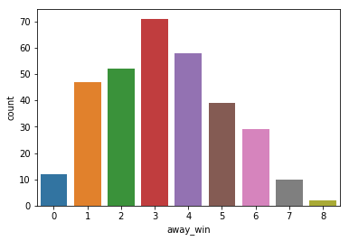

```python
# count-plot of total number of away game wins by team in general during (2009 to 2018)
sns.countplot(x='away_win', data=df)
```

There are 16 games in regular season where 8 home games and 8 away games. only 2 or 3 times it happened that some team were able to win all away games while more than 10 times some teams were not able to win even one away game. most of the times teams were able to win 3 out of 8 away games.

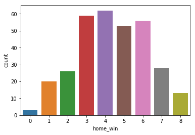

```python
# # count-plot of total number of home game wins by team in general during (2009 to 2018)
sns.countplot(x='home_win', data=df)
```

opposite to away games, more than 10 times it happened that some teams were able to win all home games while 5 or less times some teams were not able to win even one home game. usually most of the teams are likely to win 3 to 6 home games.

in next step, the data is standardized so all value we have for away-win, home-win, tie, lose are in ratio to total games  
while all other values of each columns are the average (the total / total games played).

```python
# Get weighted score for each column using the ratio
df['total_win'] = df['away_win']+df['home_win']
df['total_fg'] = df['fg_missed']+df['fg_made']
df['total_pass'] = df['complete_pass']+df['incomplete_pass']
df['total_game'] = df['away_win']+df['home_win']+df['tie']+df['lose']
# denominator cannot be zero so first set total to 1 if it's 0 before getting ratio
df['total_fg'] = np.where((df['total_fg']==0),1,df.total_fg)
df['total_pass'] = np.where((df['total_pass']==0),1,df.total_pass)
df['total_game'] = np.where((df['total_game']==0),1,df.total_game)

# overall team performance
df['win_ratio'] = df['total_win']/df['total_game']
df['away_win_ratio'] = df['away_win']/df['total_game']
df['home_win_ratio'] = df['home_win']/df['total_game']
df['tie_ratio'] = df['tie']/df['total_game']
df['lose_ratio'] = df['lose']/df['total_game']
df['total_scores_ratio'] = df['total_scores']/df['total_game']
df['penalty_ratio'] = df['penalty_yards']/df['total_game']

# offensive performance
df['qb_kneel_ratio'] = df['qb_kneel']/df['total_game']
df['fg_ratio'] = df['fg_made']/df['total_fg']
df['completion_ratio'] = df['complete_pass']/df['total_pass']

# defensive performance => fumble, qb_hit, sack, interception
df['fumble_ratio'] = df['fumble']/df['total_game']
df['qb_hit_ratio'] = df['qb_hit']/df['total_game']
df['sack_ratio'] = df['sack']/df['total_game']
df['interception_ratio'] = df['interception']/df['total_game']

df.drop(['fg_made', 'fg_missed','complete_pass','incomplete_pass','total_pass','total_fg'], axis=1,inplace=True)
df.drop(['penalty_yards','away_win', 'home_win','tie','lose','total_scores','total_win','qb_kneel','total_game'], axis=1,inplace=True)
df.drop(['fumble', 'qb_hit','sack','interception'], axis=1,inplace=True)


df_len = len(df)
chmp_list = np.full((df_len, 1), 0)
df['champion'] = chmp_list
lst_of_champs=[(2009, 'NO'), (2010, 'GB'), (2011, 'NYG'),(2012, 'BAL'), (2013, 'SEA'),
                (2014, 'NE'),(2015, 'DEN'), (2016, 'NE'), (2017, 'PHI')]

for yr_tm in lst_of_champs:
    (year,team) = yr_tm
    df['champion'] = np.where((df['year']==year)&(df['team']==team),1,df.champion)
df.head()
```

|  | year | team | win_ratio | away_win_ratio | home_win_ratio | tie_ratio | lose_ratio | total_scores_ratio | penalty_ratio | qb_kneel_ratio | fg_ratio | completion_ratio | fumble_ratio | qb_hit_ratio | sack_ratio | interception_ratio | champion |
| --- | --- | --- | --- | --- | --- | --- | --- | --- | --- | --- | --- | --- | --- | --- | --- | --- | --- |
| 0 | 2009 | ARI | 0.6250 | 0.3750 | 0.2500 | 0.0 | 0.3750 | 23.3125 | 55.3750 | 1.1875 | 0.947368 | 0.679931 | 1.1250 | 5.3125 | 2.6875 | 1.3125 | 0 |
| 1 | 2009 | ATL | 0.5625 | 0.1875 | 0.3750 | 0.0 | 0.4375 | 22.5000 | 41.5000 | 0.9375 | 0.655172 | 0.600362 | 1.3750 | 3.1875 | 1.7500 | 0.9375 | 0 |
| 2 | 2009 | BAL | 0.5625 | 0.1875 | 0.3750 | 0.0 | 0.4375 | 24.3125 | 68.0625 | 0.4375 | 0.700000 | 0.645875 | 1.2500 | 4.2500 | 2.0000 | 1.3750 | 0 |
| 3 | 2009 | BUF | 0.3750 | 0.1875 | 0.1875 | 0.0 | 0.6250 | 16.0000 | 53.4375 | 0.5000 | 0.848485 | 0.605201 | 1.5625 | 6.3125 | 2.1250 | 1.7500 | 0 |
| 4 | 2009 | CAR | 0.5000 | 0.1875 | 0.3125 | 0.0 | 0.5000 | 19.6250 | 43.6250 | 0.8750 | 0.814815 | 0.593258 | 1.8750 | 3.5625 | 1.9375 | 1.3750 | 0 |

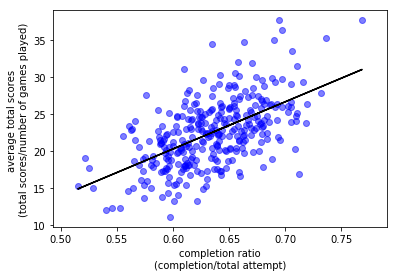

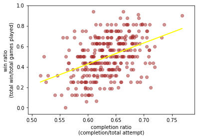

```python
X=df['completion_ratio']
Y=df['total_scores_ratio']
Y2=df['win_ratio']
plt.scatter(X, Y, alpha=0.5,color='blue')
coefs = poly.polyfit(X, Y,1)
ffit = poly.polyval(X, coefs)
plt.plot(X, ffit,c='black')
plt.ylabel('average total scores \n(total scores/number of games played)')
plt.xlabel('completion ratio\n(completion/total attempt)')
plt.show()

plt.scatter(X, Y2, alpha=0.5,color='brown')
coefs = poly.polyfit(X, Y2,1)
ffit = poly.polyval(X, coefs)
plt.plot(X, ffit,c='yellow')
print("\n\n")
plt.ylabel('win ratio \n(total win/total games played)')
plt.xlabel('completion ratio\n(completion/total attempt)')
plt.show()
```

Between the completion ratio and total scores, and between the completion ratio and win ratio have positive relations which means the team with a quarterback who can throw ball more accurately has more chance to get better scores as well as to win  
more games.

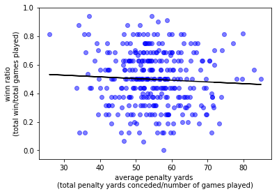

```python
X=df['penalty_ratio']
Y=df['win_ratio']
plt.scatter(X, Y, alpha=0.5,color='blue')
coefs = poly.polyfit(X, Y,1)
ffit = poly.polyval(X, coefs)
plt.plot(X, ffit,c='black')
plt.xlabel('average penalty yards \n(total penalty yards conceded/number of games played)')
plt.ylabel('winn ratio\n(total win/total games played)')
plt.show()
```

I expected to have some opposite (negative) correlation between penalty yards conceded and winning the. However, when I did the scatter plot and fit regression line, the regression line is horizontal (almost) which means that there is no relation betwween these two factors.

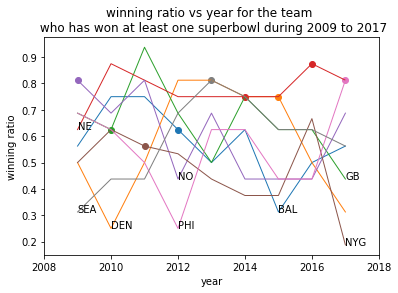

```python
df_train=df.loc[(df['year'] < 2018)]
team_with_ring=df_train.loc[(df_train['champion'] == 1)]
fig, ax = plt.subplots()
ax.set_xlim(2008,2018)
for key, grp in team_with_ring.groupby(['team']):
    df_to_plot=df_train.loc[(df_train['team'] == key)]
    df_win = df_to_plot.loc[(df_train['champion'] == 1)]
    year_win=df_win['year'].tolist()
    year_win_ratio = df_win['win_ratio'].tolist()
    plt.scatter(year_win, year_win_ratio)
    x=df_to_plot['year'].tolist()
    y=df_to_plot['win_ratio'].tolist()
    j=min(y)
    i=x[y.index(j)]
    line, = ax.plot(x,y, lw=1)
    plt.annotate(key, xy = (i,j))

plt.xlabel("year")
plt.ylabel("winning ratio")
plt.title("winning ratio vs year for the team \n who has won at least one superbowl during 2009 to 2017")
plt.show()
```

Dots on line represent that the team won superbowl in that year. It seems teams with winning ratio close to or greater than 75% are more likely to win super bowl. the only one team, New York Giant, was able to win the superbowl with winning ratio less than 60%. It's very unlikely to win the superbowl if the team has won less than 60% of total games in regular seasons(16 games). New England Patriots is the only one team who won superbowls more than once and also only superbowl winning team whose winning ratio over time is more consistent than any other team.

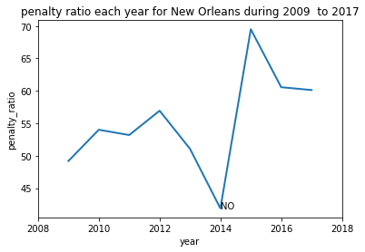

```python
fig, ax = plt.subplots()
ax.set_xlim(2008,2018)


df_to_plot=df_train.loc[(df_train['team'] == 'NO')]
x=df_to_plot['year'].tolist()
y=df_to_plot['penalty_ratio'].tolist()
j=min(y)
i=x[y.index(j)]
line, = ax.plot(x,y, lw=2)
plt.annotate('NO', xy = (i,j))

plt.title("penalty ratio each year for New Orleans during 2009  to 2017")
plt.xlabel("year")
plt.ylabel("penalty_ratio")
plt.show()
```

Tho above picture is a plot for average penalty yards conceded by New Orlean Saints to see if it had some effect after bounty scandal. the average penalty yards conceded for New Orleans reduced dramatically during suspension;however, after suspension the average penalty yards conceded has been higher than they ever had before (since 2009).

**Prediction of next coming fixtures and whether Ravens will make it to the either Playoff or wildcard-entry**  
Libraries from sklearn is used to get prediction  
Inependent Variables are (X) :  
home-team  
away-team  
home game win to total games played ratio (total home game wins / total games played) of home team  
average total scores (total scores / total games played) of home game  
away game win to total games played ratio (total away game wins / total games played) of away team  
average total scores (total scores / total games played) of away team  
Dependent Variable (Y) :  
home team win (binary if home win then 1 else 0) here a chance of draw is ignored, and count it as 0. It's very  
unlikely to have draw and therefore winning is more important to get to the playoff or wildcard round. Hence, we are  
only interested to figure out whether team win or lose (draw is counted as lose)  
Now we are going to add more information to dataframe for prediction (pred_df) which we created  
in Data Wrangling Part 1

```python
# col_names=['year','home_team','away_team','home_win_team','avg_ht_hw','avg_at_aw','avg']
col_names=['year','home_team','away_team','home_team_win','avg_home_win_ht','avg_total_scores_ht']
new_pred_df = pd.DataFrame(columns=col_names)
for key, grp in pred_df.groupby(['year','home_team']):
    row = df.loc[(df['year'] == key[0]) & (df['team'] == key[1])]
    x=row.iloc[0]['home_win_ratio']
    y=row.iloc[0]['total_scores_ratio'] #  for home_team
    l = len(grp)
    df1=grp.copy()
    df1['avg_home_win_ht'] = [x]*l
    df1['avg_total_scores_ht'] = [y]*l
    new_pred_df = new_pred_df.append(df1)

new_pred_df.head()

col_names.append('avg_away_win_at');col_names.append('avg_total_scores_at')
pred_df = new_pred_df
new_pred_df = pd.DataFrame(columns=col_names)
for key, grp in pred_df.groupby(['year','away_team']):
    row = df.loc[(df['year'] == key[0]) & (df['team'] == key[1])]
    x=row.iloc[0]['away_win_ratio']
    y=row.iloc[0]['total_scores_ratio'] #  for away team
    l = len(grp)
    df1=grp.copy()
    df1['avg_away_win_at'] = [x]*l
    df1['avg_total_scores_at'] = [y]*l
    new_pred_df = new_pred_df.append(df1)

new_pred_df=new_pred_df[['year','home_team','away_team','avg_home_win_ht','avg_total_scores_ht',
                         'avg_away_win_at','avg_total_scores_at','home_team_win']]
new_pred_df.head()
```

|  | year | home_team | away_team | avg_home_win_ht | avg_total_scores_ht | avg_away_win_at | avg_total_scores_at | home_team_win |
| --- | --- | --- | --- | --- | --- | --- | --- | --- |
| 117 | 2009 | CHI | ARI | 0.3125 | 20.3125 | 0.375 | 23.3125 | 0 |
| 212 | 2009 | DET | ARI | 0.1250 | 16.0625 | 0.375 | 23.3125 | 0 |
| 19 | 2009 | JAX | ARI | 0.3125 | 18.1250 | 0.375 | 23.3125 | 0 |
| 154 | 2009 | LA | ARI | 0.0000 | 11.0000 | 0.375 | 23.3125 | 0 |
| 101 | 2009 | NYG | ARI | 0.2500 | 24.8750 | 0.375 | 23.3125 | 0 |

$$ Column-Name \space Detail $$
avg_home_win_ht : total home game win / total games played for home team
avg_total_scores_ht : average total scores per game for home team
avg_away_win_at : total away win / total games played for away team
avg_total_scores_at : average total scores for away team
home_team_win : if home team win then 1 else 0

In next step, we are training logistic regression model using our data so we can use it to predict future games (week 12)

```python
my_df=new_pred_df.copy()
le = preprocessing.LabelEncoder()
le.fit(my_df['home_team'])

# Since we cannot use string variables we must change
# columns with string variable to continuous variables
# therefore we LabelEncoder to transform columns with
# names of home-team and names of away-team from strings
# continuous variable (in this case it's strings to integers)
my_df['home_team'] = le.transform(my_df['home_team'])
my_df['away_team'] = le.transform(my_df['away_team'])

# get dummy variable to use data to train model
home_team = pd.get_dummies(my_df['home_team'])
away_team = pd.get_dummies(my_df['away_team'])
my_df = pd.concat([my_df,home_team,away_team],axis=1)

# Since we already concatenated home-team and away-team
# we can drop two original columns
my_df.drop('home_team',axis=1,inplace=True)
my_df.drop('away_team',axis=1,inplace=True)

# X contains all (real) independent variables that are used to
# predict the result
X=my_df.drop('home_team_win',axis=1)

# y is the column which contains (real) values we want to predict
y=my_df['home_team_win']

# the above line of code gives y as list of object datatype so
# we change list of object datatype to list of integer
y = list(map(int, y))

# split data into ~2/3 and ~1/3 to train and test data we have
X_train, X_test, y_train, y_test = train_test_split(X, y, test_size=0.33, random_state=1)

# initialize model (logistic regression model) and train using train data
model = LogisticRegression()
model.fit(X_train,y_train)

# once we trained the model, get predictions from X_test
predictions = model.predict(X_test)
```

```python
print(classification_report(y_test,predictions))
```

```
             precision    recall  f1-score   support

          0       0.74      0.68      0.71       362
          1       0.76      0.81      0.78       451

avg / total       0.75      0.75      0.75       813
```

```python
accuracy_score(y_test,predictions)
```

```
0.7515375153751538
```

The above score is accuracy score wich means the prediction we get is (score value) * 100% chance that the prediction is right.

Now we use the above trained logistic regression model to find the result of future games for Ravens.

```python
p_df=new_pred_df.loc[(new_pred_df['year'] == 2018)]
year =[2018]*6
home_team = ['BAL','ATL','KC','BAL','LAC','BAL']
away_team = ['OAK','BAL','BAL','TB','BAL','CLE']
avg_home_win_ht = []
avg_total_scores_ht = []
avg_away_win_at = []
avg_total_scores_at = []

for x in (home_team):
    h_team=p_df.loc[(p_df['home_team']==x)].iloc[0]
    ht_avg_home_win = h_team['avg_home_win_ht']
    ht_avg_scores = h_team['avg_total_scores_ht']
    avg_home_win_ht.append(ht_avg_home_win)
    avg_total_scores_ht.append(ht_avg_scores)

for x in (away_team):
    a_team=p_df.loc[(p_df['away_team']==x)].iloc[0]
    at_avg_away_win = a_team['avg_away_win_at']
    at_avg_scores = a_team['avg_total_scores_at']
    avg_away_win_at.append(at_avg_away_win)
    avg_total_scores_at.append(at_avg_scores)

col_names=['year','home_team','away_team','avg_home_win_ht','avg_total_scores_ht',
           'avg_away_win_at','avg_total_scores_at']
my_data = pd.DataFrame()
my_data['year']=year; my_data['home_team']=home_team;  my_data['away_team']=away_team;
my_data['avg_home_win_ht'] = avg_home_win_ht; my_data['avg_total_scores_ht']=avg_total_scores_ht
my_data['avg_away_win_at']=avg_away_win_at;   my_data['avg_total_scores_at']=avg_total_scores_at;
my_data.head(6)
```

|  | year | home_team | away_team | avg_home_win_ht | avg_total_scores_ht | avg_away_win_at | avg_total_scores_at |
| --- | --- | --- | --- | --- | --- | --- | --- |
| 0 | 2018 | BAL | OAK | 0.300000 | 23.700000 | 0.1 | 16.9 |
| 1 | 2018 | ATL | BAL | 0.300000 | 26.300000 | 0.2 | 23.7 |
| 2 | 2018 | KC | BAL | 0.454545 | 36.363636 | 0.2 | 23.7 |
| 3 | 2018 | BAL | TB | 0.300000 | 23.700000 | 0.1 | 26.6 |
| 4 | 2018 | LAC | BAL | 0.300000 | 26.200000 | 0.2 | 23.7 |
| 5 | 2018 | BAL | CLE | 0.300000 | 23.700000 | 0.0 | 21.8 |

```python
my_df=new_pred_df.copy()
my_df.drop('home_team_win',axis=1,inplace=True)
my_df=my_df.append(my_data, ignore_index=True)
my_df['home_team'] = le.transform(my_df['home_team'])
my_df['away_team'] = le.transform(my_df['away_team'])

home_team = pd.get_dummies(my_df['home_team'])
away_team = pd.get_dummies(my_df['away_team'])
my_df = pd.concat([my_df,home_team,away_team],axis=1)
my_df.drop('home_team',axis=1,inplace=True)
my_df.drop('away_team',axis=1,inplace=True)

X=my_df.tail(6)
predictions = model.predict(X)
my_data.drop(['avg_home_win_ht','avg_total_scores_ht','avg_away_win_at','avg_total_scores_at'],axis=1,inplace=True)
my_data['predicted_home_team_win'] = predictions
my_data.head(6)
```

|  | year | home_team | away_team | predicted_home_team_win |
| --- | --- | --- | --- | --- |
| 0 | 2018 | BAL | OAK | 1 |
| 1 | 2018 | ATL | BAL | 1 |
| 2 | 2018 | KC | BAL | 1 |
| 3 | 2018 | BAL | TB | 1 |
| 4 | 2018 | LAC | BAL | 1 |
| 5 | 2018 | BAL | CLE | 1 |

The prediction says that Baltimore more likely to lose all away games, while may win all home games. So Baltimore more  
likely to win 3 more games and will have 8 wins total by the end of the regular season 2018.

Updated after week 13 : Baltimore played two games against OAK and ATL. They won away game against Atlanta. It may happened because our main quarterback Joe Flacco have been out due to injury and since then Baltimores are more focused on running the ball than passing it. Moreovere, I have not used defensive and returning team performance who had scored (two touchdown) against Atlanta.

```python
p_df=new_pred_df.loc[(new_pred_df['year'] == 2018)]
home_team = ['DET','DAL','NO','PHI','BUF','CAR','BAL','TB',
            'CIN','NYJ','LAC','DEN','IND','MIN','HOU']
away_team = ['CHI','WAS','ATL','NYG','JAX','SEA','OAK','SF',
            'CLE','NE','ARI','PIT','MIA','GB','TEN']
l=len(home_team)
year =[2018]*l
avg_home_win_ht = []
avg_total_scores_ht = []
avg_away_win_at = []
avg_total_scores_at = []

for x in (home_team):
    h_team=p_df.loc[(p_df['home_team']==x)].iloc[0]
    ht_avg_home_win = h_team['avg_home_win_ht']
    ht_avg_scores = h_team['avg_total_scores_ht']
    avg_home_win_ht.append(ht_avg_home_win)
    avg_total_scores_ht.append(ht_avg_scores)

for x in (away_team):
    a_team=p_df.loc[(p_df['away_team']==x)].iloc[0]
    at_avg_away_win = a_team['avg_away_win_at']
    at_avg_scores = a_team['avg_total_scores_at']
    avg_away_win_at.append(at_avg_away_win)
    avg_total_scores_at.append(at_avg_scores)

col_names=['year','home_team','away_team','avg_home_win_ht','avg_total_scores_ht',
           'avg_away_win_at','avg_total_scores_at']
my_data = pd.DataFrame()
my_data['year']=year; my_data['home_team']=home_team;  my_data['away_team']=away_team;
my_data['avg_home_win_ht'] = avg_home_win_ht; my_data['avg_total_scores_ht']=avg_total_scores_ht
my_data['avg_away_win_at']=avg_away_win_at;   my_data['avg_total_scores_at']=avg_total_scores_at;
```

```python
my_df=new_pred_df.copy()
my_df.drop('home_team_win',axis=1,inplace=True)
my_df=my_df.append(my_data, ignore_index=True)
# le = preprocessing.LabelEncoder()
# le.fit(my_df['home_team'])
# # le.transform(['BAL','NO'])
# # le.inverse_transform([1, 2])
my_df['home_team'] = le.transform(my_df['home_team'])
my_df['away_team'] = le.transform(my_df['away_team'])

home_team = pd.get_dummies(my_df['home_team'])
away_team = pd.get_dummies(my_df['away_team'])
my_df = pd.concat([my_df,home_team,away_team],axis=1)
my_df.drop('home_team',axis=1,inplace=True)
my_df.drop('away_team',axis=1,inplace=True)

X=my_df.tail(len(my_data))
predictions = model.predict(X)
my_data.drop(['avg_home_win_ht','avg_total_scores_ht','avg_away_win_at','avg_total_scores_at'],axis=1,inplace=True)
my_data['predicted_home_team_win'] = predictions
```

My prediction for nfl week 12 is as follows :

```python
my_data.head(20)
```

|  | year | home_team | away_team | predicted_home_team_win |
| --- | --- | --- | --- | --- |
| 0 | 2018 | DET | CHI | 0 |
| 1 | 2018 | DAL | WAS | 0 |
| 2 | 2018 | NO | ATL | 1 |
| 3 | 2018 | PHI | NYG | 0 |
| 4 | 2018 | BUF | JAX | 0 |
| 5 | 2018 | CAR | SEA | 1 |
| 6 | 2018 | BAL | OAK | 1 |
| 7 | 2018 | TB | SF | 1 |
| 8 | 2018 | CIN | CLE | 1 |
| 9 | 2018 | NYJ | NE | 0 |
| 10 | 2018 | LAC | ARI | 1 |
| 11 | 2018 | DEN | PIT | 0 |
| 12 | 2018 | IND | MIA | 1 |
| 13 | 2018 | MIN | GB | 1 |
| 14 | 2018 | HOU | TEN | 1 |

From the above prediction Steelers will win the game against Broncos. Steelers win next game means they will have  
8 wins and 1 ties by the end of next week while from our previous prediction table Ravens will have 8 wins total by  
the end of the regualar seasons. Therefore, Ravens very unlikely to top the AFC North this season. Moreover, by the end  
of the week 11, there are six teams along Ravens as candidate who may qualify for wild card, and these teams and their  
total wins so far  
are presented below :

```
 Team                          Wins
```

```
              after-week-11        after-week-12-prediction
```

```
 Ravens           5                          6
```

```
 Bangles          5                          6
```

```
 Chargers         7                          8
```

```
 Dolphins         5                          5
```

```
 Titans           5                          5
```

```
 Colts            5                          6
```

Teams Ravens,Bangles,Chargers, and Colts will be in wild card hunt after week 12.

So after week 12, Ravens,Bangles,Chargers,and Colts will compete for wild card entry;however,  
according to our previous prediction of Baltimore's future games, Baltimore will lose game against  
Chargers. Since Chargers will have at least 9 wins Chargers will be ahead of Ravens by the end of the  
regular season. So we only need to check whther Ravens will have more wins than any other teams except  
Charger to find out if Ravens is more likey to qualify for wild card round. The teams along Ravens who will  
compete for wild card round after week 12 predictions are Bangles, and Colts. To find out whether Ravens will  
qualify for wild round or not we do prediction of futures games of Bangles and Colts in next section and see  
what happens  
Updated after week 12 games were played: 9 out of 15 games were predicted correctly.  
I've found one more interesting thing about prediction.  
prediction for 6 games that are wrong, 3 winning teams win the game leading by only 3 points.  
On the other hand, 8 out of those 9 correctly predicted games win the game leading by at least 7 points.  
Above the model said accuracy_score is 75.15% (0.7515375153751538), and the result I've got is 60% (9/15) accurate.  
Note : the accuracy_score may vary due to update on data set in next coming date  
Predict the results of next coming games of Bangles and Colts using above model with similar technique we used for  
Ravens

```python
# future games prediction of Colts
p_df=new_pred_df.loc[(new_pred_df['year'] == 2018)]
year =[2018]*6
home_team = ['IND','JAX','HOU','IND','IND','TEN']
away_team = ['MIA','IND','IND','DAL','NYG','IND']
avg_home_win_ht = []
avg_total_scores_ht = []
avg_away_win_at = []
avg_total_scores_at = []

for x in (home_team):
    h_team=p_df.loc[(p_df['home_team']==x)].iloc[0]
    ht_avg_home_win = h_team['avg_home_win_ht']
    ht_avg_scores = h_team['avg_total_scores_ht']
    avg_home_win_ht.append(ht_avg_home_win)
    avg_total_scores_ht.append(ht_avg_scores)

for x in (away_team):
    a_team=p_df.loc[(p_df['away_team']==x)].iloc[0]
    at_avg_away_win = a_team['avg_away_win_at']
    at_avg_scores = a_team['avg_total_scores_at']
    avg_away_win_at.append(at_avg_away_win)
    avg_total_scores_at.append(at_avg_scores)

col_names=['year','home_team','away_team','avg_home_win_ht','avg_total_scores_ht',
           'avg_away_win_at','avg_total_scores_at']
my_data = pd.DataFrame()
my_data['year']=year; my_data['home_team']=home_team;  my_data['away_team']=away_team;
my_data['avg_home_win_ht'] = avg_home_win_ht; my_data['avg_total_scores_ht']=avg_total_scores_ht
my_data['avg_away_win_at']=avg_away_win_at;   my_data['avg_total_scores_at']=avg_total_scores_at;
my_data.head(6)

# PREDICTION TABLE OF GAMES FOR COLTS
my_df=new_pred_df.copy()
my_df.drop('home_team_win',axis=1,inplace=True)
my_df=my_df.append(my_data, ignore_index=True)
my_df['home_team'] = le.transform(my_df['home_team'])
my_df['away_team'] = le.transform(my_df['away_team'])

home_team = pd.get_dummies(my_df['home_team'])
away_team = pd.get_dummies(my_df['away_team'])
my_df = pd.concat([my_df,home_team,away_team],axis=1)
my_df.drop('home_team',axis=1,inplace=True)
my_df.drop('away_team',axis=1,inplace=True)

X=my_df.tail(6)
predictions = model.predict(X)
my_data.drop(['avg_home_win_ht','avg_total_scores_ht','avg_away_win_at','avg_total_scores_at'],axis=1,inplace=True)
my_data['predicted_home_team_win'] = predictions
my_data.head(6)
```

|  | year | home_team | away_team | predicted_home_team_win |
| --- | --- | --- | --- | --- |
| 0 | 2018 | IND | MIA | 1 |
| 1 | 2018 | JAX | IND | 0 |
| 2 | 2018 | HOU | IND | 1 |
| 3 | 2018 | IND | DAL | 1 |
| 4 | 2018 | IND | NYG | 1 |
| 5 | 2018 | TEN | IND | 0 |

According to the above prediction,after week 11, Colts will win 5 out of 6 games which means they will have  
total 10 wins by the end of the regular season. From previous and this predictions, we can see that by the  
end of the regular season Ravens will be behind Chargers and Colts. There is still some chance for ravens to  
get to the wild card entry for that we need to predic the result of future games for the Texas.  
So in next section I have table of prediction of future games of Houston Texas from week 12 to week 17

```python
# future games prediction of Colts
p_df=new_pred_df.loc[(new_pred_df['year'] == 2018)]
year =[2018]*6
home_team = ['HOU','HOU','HOU','NYJ','PHI','HOU']
away_team = ['TEN','CLE','IND','HOU','HOU','JAX']
avg_home_win_ht = []
avg_total_scores_ht = []
avg_away_win_at = []
avg_total_scores_at = []

for x in (home_team):
    h_team=p_df.loc[(p_df['home_team']==x)].iloc[0]
    ht_avg_home_win = h_team['avg_home_win_ht']
    ht_avg_scores = h_team['avg_total_scores_ht']
    avg_home_win_ht.append(ht_avg_home_win)
    avg_total_scores_ht.append(ht_avg_scores)

for x in (away_team):
    a_team=p_df.loc[(p_df['away_team']==x)].iloc[0]
    at_avg_away_win = a_team['avg_away_win_at']
    at_avg_scores = a_team['avg_total_scores_at']
    avg_away_win_at.append(at_avg_away_win)
    avg_total_scores_at.append(at_avg_scores)

col_names=['year','home_team','away_team','avg_home_win_ht','avg_total_scores_ht',
           'avg_away_win_at','avg_total_scores_at']
my_data = pd.DataFrame()
my_data['year']=year; my_data['home_team']=home_team;  my_data['away_team']=away_team;
my_data['avg_home_win_ht'] = avg_home_win_ht; my_data['avg_total_scores_ht']=avg_total_scores_ht
my_data['avg_away_win_at']=avg_away_win_at;   my_data['avg_total_scores_at']=avg_total_scores_at;
my_data.head(6)

# PREDICTION TABLE OF GAMES FOR COLTS
my_df=new_pred_df.copy()
my_df.drop('home_team_win',axis=1,inplace=True)
my_df=my_df.append(my_data, ignore_index=True)
my_df['home_team'] = le.transform(my_df['home_team'])
my_df['away_team'] = le.transform(my_df['away_team'])

home_team = pd.get_dummies(my_df['home_team'])
away_team = pd.get_dummies(my_df['away_team'])
my_df = pd.concat([my_df,home_team,away_team],axis=1)
my_df.drop('home_team',axis=1,inplace=True)
my_df.drop('away_team',axis=1,inplace=True)

X=my_df.tail(6)
predictions = model.predict(X)
my_data.drop(['avg_home_win_ht','avg_total_scores_ht','avg_away_win_at','avg_total_scores_at'],axis=1,inplace=True)
my_data['predicted_home_team_win'] = predictions
my_data.head(6)
```

|  | year | home_team | away_team | predicted_home_team_win |
| --- | --- | --- | --- | --- |
| 0 | 2018 | HOU | TEN | 1 |
| 1 | 2018 | HOU | CLE | 1 |
| 2 | 2018 | HOU | IND | 1 |
| 3 | 2018 | NYJ | HOU | 0 |
| 4 | 2018 | PHI | HOU | 0 |
| 5 | 2018 | HOU | JAX | 1 |

By looking at the table of Houston games prediction, we can clearly say that Houston Texas are more likely to win all of  
their coming games and their total wins by the end of the week 11 is 7 so even if they win only two more games they will  
have more wins (9) than Ravens (8) by the end of the regular season, but they are likely to win all upcoming games.

From all this predictions and analysis, we can say that :  
By the end of the regular season, Baltimore Ravens will not finish as group division chapions (top team of the AFC North)  
and plus they will be behind Chargers,Texas, and Colts on number of total wins.Therefore, Ravens will not make it to either  
Playoff or Wild Card entry. Even after all these analysis, I see that it's very hard for Ravens to make it to Playoff, as a  
Baltimore Ravens fan, I still have some hope they will make it to the wild card or playoff and will go all the way to the  
final (Superbowls)  
GO RAVENS

The video in this link explains more about logistic regression https://www.youtube.com/watch?v=VCJdg7YBbAQ  
Documentatio of sklearn logistic regression is in the below link :  
https://scikit-learn.org/stable/modules/generated/sklearn.linear_model.LogisticRegression.html  
The source of data that is used in this project : https://github.com/ryurko/nflscrapR-data  
This project is done on Jupyter Notebook on Anaconda 3 and then pushed to the github repository from github Desktop App  
Github Desktop Download link : https://desktop.github.com/  
Quick and short Github Desktop Tutorial if you are using it for first time : https://www.youtube.com/watch?v=77W2JSL7-r8  
Anaconda source and documentation : https://www.anaconda.com/download/  
Jupyter Notebook source and documentation : https://jupyter.org/  
The whole project is written in python. Libraries and what they are used for in this project are :  
pandas : Dataframe matplotlib : to plot data and do linear regression numpy : list and dataframe minipulation seaborn : visualization and analysis of data (EDA) i.e. count-plot sklearn : Logistic Regression , Accuracy measurement of prediction

[figure not shown]